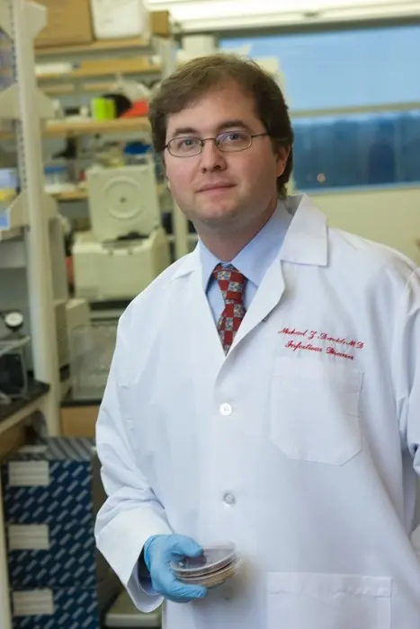

**Michael Z. David, MD, PhD** (he/him) is Assistant Professor at the University of Pennsylvania. Prior to joining the Motion Lab, he studied the molecular and clinical epidemiology of Staphylococcus aureus in the community and in healthcare facilities.. He is now studying the adaptation of S. aureus to the human body and to the healthcare environment. He is interested in the prevention of S. aureus infections and strain differences that underlie infections with, transmission of, and colonization of the human body by S. aureus. He enjoys reading history, photography, and travel. Additional information can be found [here](https://www.cceb.med.upenn.edu/bio/michael-zdenek-david-ms-md-phd).

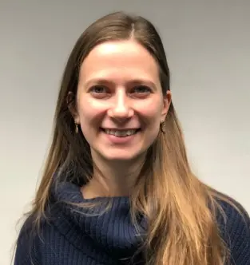

**Lauren Dutcher, MD, MSCE** (she/her) is Assistant Professor at the University of Pennsylvania. Dr. Dutcher’s research focuses on understanding antimicrobial utilization patterns and assessing the impact of antimicrobial stewardship interventions on patient and population outcomes. Outside of work, Dr. Dutcher enjoys hiking, travel, and trying new Philadelphia restaurants. Additional information can be found [here](https://www.med.upenn.edu/apps/faculty/index.php/g349/p8363266).

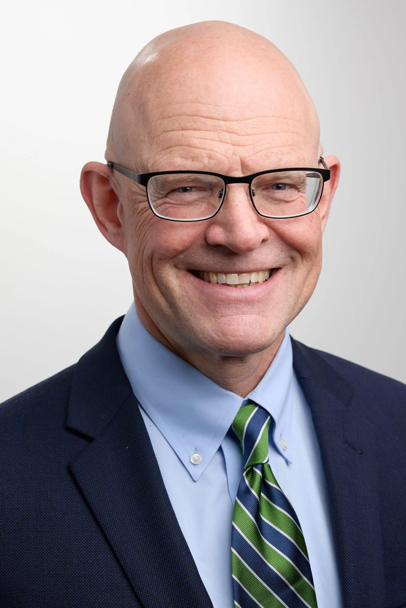

**Ebbing Lautenbach, MD, MPH, MSCE** (he/his/him) is Robert Austrian Professor of Medicine and Epidemiology at the University of Pennsylvania. Prior to joining the MOTION lab, he studied the epidemiology of antimicrobial resistance in healthcare and community settings. His work focuses on understanding the complex interplay of the clinical and molecular epidemiology of antibiotic-resistant colonization and infection. This work focuses primarily on multidrug-resistant gram-negative bacteria in hospital and community settings, both in domestic and international sites. Outside of lab, he enjoys running (most recently the Acadia Marathon in Maine), playing guitar, and traveling. Additional information can be found [here](https://www.cceb.med.upenn.edu/bio/ebbing-lautenbach-md-mph-msce).

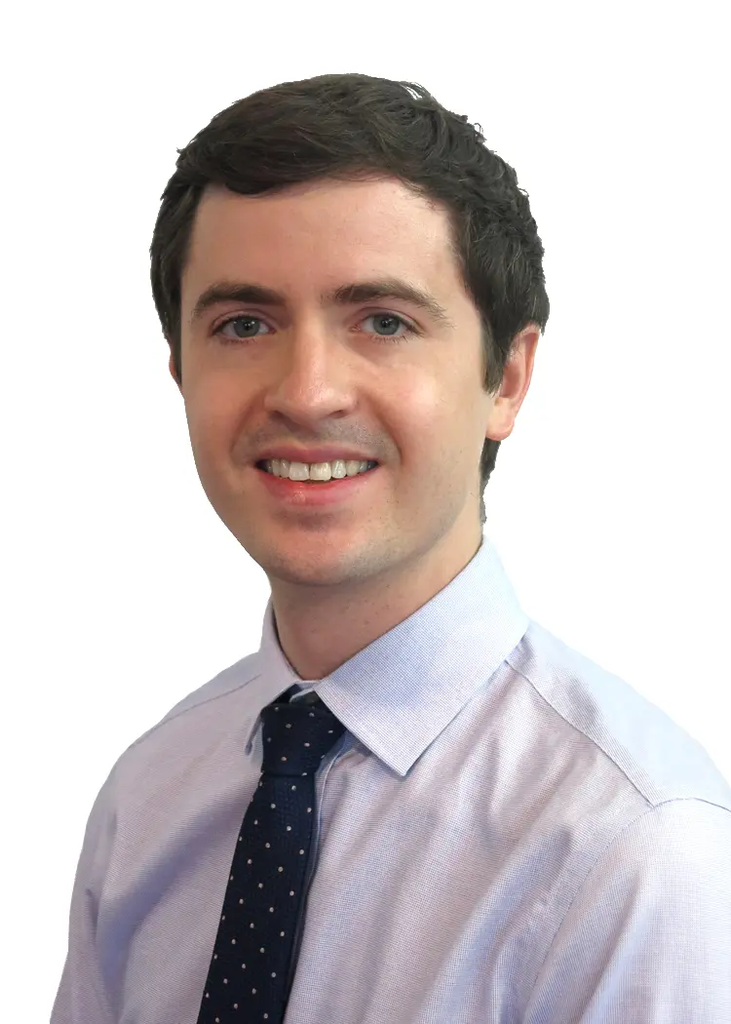

**Matthew J. Ziegler, MD, MSCE** (he/his/him) is Assistant Professor of Medicine at the University of Pennsylvania. His clinical research program focuses on the prevention of healthcare-associated infections in immunocompromised patients and the molecular epidemiology of multidrug-resistant organisms (MDROs) within the hospital built environment. Outside of work, he enjoys woodworking and going to Philly parks with his family.